# Введение в работу с RMarkdown

Дмитрий Серебренников

# Это заголовок раздела нашего Rmd

Теперь три вертикальных пробела:

Сделаем чанк. Либо через кнопку в виде зелёной буквой ‘c’ (и там выбираем ‘R’) на панели сразу над окном кода, либо, что более удобно - через комбинацию Cntrl+Alt+I для Windows и Cmnd+Alt+I в Mac

```r
2+2
```

```
## [1] 4
```

## Это подзаголовок нашего Rmd

Ещё три вертикальных пробела:

### А это подзаголовок нашего подзаголовка

Посмотрим на то, как отображаются данные:

```r
data <- iris # Известный предустановленный датасет
head(data)
```

```
##   Sepal.Length Sepal.Width Petal.Length Petal.Width Species
## 1          5.1         3.5          1.4         0.2  setosa
## 2          4.9         3.0          1.4         0.2  setosa
## 3          4.7         3.2          1.3         0.2  setosa
## 4          4.6         3.1          1.5         0.2  setosa
## 5          5.0         3.6          1.4         0.2  setosa
## 6          5.4         3.9          1.7         0.4  setosa
```

График:

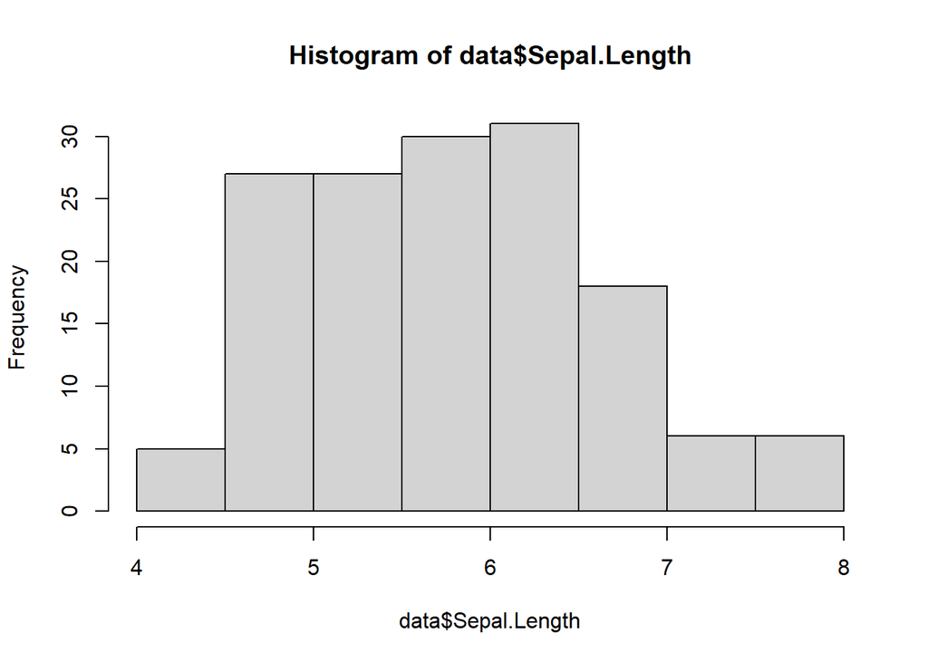

Место для красивой картинки:

[figure not shown]

**А откуда она была взята?**

[Ссылка](https://bioinf.me/)

### Несколько слов о форматировании

*Этот текст будет курсивом*

*Этот текст будет курсивом*

**Этот текст будет жирным**

**Этот текст будет жирным**

Этот текст будет зачёркнутым

А вот тут формула: $E = mc^2$

И ещё одна: $S^2 = \frac{\sum(x_i - \bar{x_i})}{n-1}$

- Буллет поинт 1
  - Его пояснение
  - Его пояснение 2
    - Пояснение пояснения
- Буллет поинт 2
1. Автоматическая нумерация 1
2. Автоматическая нумерация 2
1. Номер списка 1
- Буллетпоинт к 1
2. Номер списка 2

Альтернатива:

- 1. Элемент
  - 1.1. Пояснение
  - 1.2. Пояснение
- 2. Элемент

Пожалуй самый странный способ рисовать таблицы вручную, но вдруг:

| Название колонки | Название колонки 2 |
| --- | --- |
| a | b |
| c | d |

Обычно таблицы делаются с помощью специального [генератора](https://www.tablesgenerator.com/markdown_tables).

В завершении - к Rmd подсоединяются бесчисленные возможности [LaTeX](https://www.latex-project.org/) и языка HTML, что делает его невероятно гибким, но помните, всю специфику HTML. Например обычный список в нём будет написан вот так:

### Альтернатива:

- Элемент 1
- Элемент 2
- Элемент 3

# Полезные ссылки

- R Markdown [Cheat Sheet](https://www.rstudio.com/wp-content/uploads/2015/02/rmarkdown-cheatsheet.pdf)
- Мороз Г. - [RMarkdown: от документа до динамического сайта](https://agricolamz.github.io/2018_ANDAN_course_winter/)
- Yihui Xie, J. J. Allaire, G G. - [R Markdown: The Definitive Guide](https://bookdown.org/yihui/rmarkdown/)
- Евгений Матеров - [Введение в Quarto](https://meetups.rintro.ru/p/4-mar-2023-eu-spb-meetup/)